# Classification_tree_dt_1

mayank

April 1, 2017

## Libraries

```r
setwd("C:\\Users\\Mayank\\Desktop\\Projects\\Decision_Trees")
library(dplyr) # a grammar of data manipulation
library(rpart) #Recursive Partitioning and Regression Trees
library(irr) #Various Coefficients of Interrater Reliability and Agreement
library(caret) #Classification and Regression Training
library(rattle) #display rattle user interface point & click interface
```

```r
library(rpart.plot) #Plot an rpart model. A simplified interface to the prp function.
library(RColorBrewer) #ColorBrewer palettes
```

## Decision tree classifier to predict good and bad customer

## decide good and bad customer based on how much they spent relative to average expenditure to total population

## if > average exp = good customer or else bad customer

## 1 = Good CUstomer; 0 = Bad Customer

## Importing data

```r
dm <- read.csv("dm.csv",stringsAsFactors = FALSE)
str(dm)
```

```
## 'data.frame':    1000 obs. of  11 variables:
##  $ Age        : chr  "Old" "Middle" "Young" "Middle" ...
##  $ Gender     : chr  "Female" "Male" "Female" "Male" ...
##  $ OwnHome    : chr  "Own" "Rent" "Rent" "Own" ...
##  $ Married    : chr  "Single" "Single" "Single" "Married" ...
##  $ Location   : chr  "Far" "Close" "Close" "Close" ...
##  $ Salary     : int  47500 63600 13500 85600 68400 30400 48100 68400 51900 80700 ...
##  $ Children   : int  0 0 0 1 0 0 0 0 3 0 ...
##  $ History    : chr  "High" "High" "Low" "High" ...
##  $ Catalogs   : int  6 6 18 18 12 6 12 18 6 18 ...
##  $ AmountSpent: int  755 1318 296 2436 1304 495 782 1155 158 3034 ...
##  $ Cust_Id    : int  247 127 479 475 151 320 804 790 43 475 ...
```

```r
dim(dm)
```

```
## [1] 1000   11
```

```r
head(dm)
```

```
##      Age Gender OwnHome Married Location Salary Children History Catalogs
## 1    Old Female     Own  Single      Far  47500        0    High        6
## 2 Middle   Male    Rent  Single    Close  63600        0    High        6
## 3  Young Female    Rent  Single    Close  13500        0     Low       18
## 4 Middle   Male     Own Married    Close  85600        1    High       18
## 5 Middle Female     Own  Single    Close  68400        0    High       12
## 6  Young   Male     Own Married    Close  30400        0     Low        6
##   AmountSpent Cust_Id
## 1         755     247
## 2        1318     127
## 3         296     479
## 4        2436     475
## 5        1304     151
## 6         495     320
```

```r
summary(dm)
```

```
##      Age               Gender            OwnHome
##  Length:1000        Length:1000        Length:1000
##  Class :character   Class :character   Class :character
##  Mode  :character   Mode  :character   Mode  :character
##
##
##
##    Married            Location             Salary          Children
##  Length:1000        Length:1000        Min.   : 10100   Min.   :0.000
##  Class :character   Class :character   1st Qu.: 29975   1st Qu.:0.000
##  Mode  :character   Mode  :character   Median : 53700   Median :1.000
##                                        Mean   : 56104   Mean   :0.934
##                                        3rd Qu.: 77025   3rd Qu.:2.000
##                                        Max.   :168800   Max.   :3.000
##    History             Catalogs      AmountSpent        Cust_Id
##  Length:1000        Min.   : 6.00   Min.   :  38.0   Min.   :  12.0
##  Class :character   1st Qu.: 6.00   1st Qu.: 488.2   1st Qu.: 316.8
##  Mode  :character   Median :12.00   Median : 962.0   Median : 636.0
##                     Mean   :14.68   Mean   :1216.8   Mean   : 643.9
##                     3rd Qu.:18.00   3rd Qu.:1688.5   3rd Qu.: 955.5
##                     Max.   :24.00   Max.   :6217.0   Max.   :1297.0
```

```r
colSums(is.na(dm))
```

```
##         Age      Gender     OwnHome     Married    Location      Salary
##           0           0           0           0           0           0
##    Children     History    Catalogs AmountSpent     Cust_Id
##           0         303           0           0           0
```

```r
#History has missing values : 303
```

## Data Exploration & Preparation

```r
dm <- dm %>% mutate(history1 = ifelse(is.na(History),"Missing",as.character(History)))
dm <- dm %>% select(-History)
dm$history1 <- as.factor(dm$history1)
```

```r
dm <- dm %>% mutate(Target = ifelse(AmountSpent> mean(AmountSpent),1,0))
dm <- dm %>% select(-AmountSpent)
```

```r
dm$Children <- as.factor(dm$Children)
dm$Catalogs <- as.factor(dm$Catalogs)
```

## Modelling

```r
mod1 <- rpart(formula = dm$Target~.,data = dm[,-9],control = rpart.control(minsplit = 2,cp = 0.002,maxdepth = 7),method = "class",parms = list(split = "gini") )
summary(mod1)
```

```
## Call:
## rpart(formula = dm$Target ~ ., data = dm[, -9], method = "class",
##     parms = list(split = "gini"), control = rpart.control(minsplit = 2,
##         cp = 0.002, maxdepth = 7))
##   n= 1000
##
##            CP nsplit rel error    xerror       xstd
## 1 0.498746867      0 1.0000000 1.0000000 0.03881064
## 2 0.100250627      1 0.5012531 0.5338346 0.03244922
## 3 0.012531328      3 0.3007519 0.3182957 0.02638980
## 4 0.010025063      4 0.2882206 0.3283208 0.02674069
## 5 0.007518797      5 0.2781955 0.3157895 0.02630075
## 6 0.004177109     10 0.2406015 0.2907268 0.02537945
## 7 0.003759398     14 0.2230576 0.2832080 0.02509159
## 8 0.002506266     16 0.2155388 0.2882206 0.02528411
## 9 0.002000000     24 0.1954887 0.3032581 0.02584724
##
## Variable importance
## history1   Salary Catalogs Children  Married      Age  OwnHome Location
##       49       25        9        6        6        4        1        1
##
## Node number 1: 1000 observations,    complexity param=0.4987469
##   predicted class=0  expected loss=0.399  P(node) =1
##     class counts:   601   399
##    probabilities: 0.601 0.399
##   left son=2 (745 obs) right son=3 (255 obs)
##   Primary splits:
##       history1 splits as  RLLL,       improve=165.16720, (0 missing)
##       Salary   < 51050  to the left,  improve=160.49930, (0 missing)
##       Married  splits as  RL,         improve= 87.70147, (0 missing)
##       Age      splits as  RRL,        improve= 76.57248, (0 missing)
##       Catalogs splits as  LLRR,       improve= 74.17238, (0 missing)
##   Surrogate splits:
##       Salary < 76850  to the left,  agree=0.787, adj=0.165, (0 split)
##
## Node number 2: 745 observations,    complexity param=0.1002506
##   predicted class=0  expected loss=0.2308725  P(node) =0.745
##     class counts:   573   172
##    probabilities: 0.769 0.231
##   left son=4 (524 obs) right son=5 (221 obs)
```

[output cut: 429 more lines]

```
##
## Node number 179: 7 observations
##   predicted class=1  expected loss=0.1428571  P(node) =0.007
##     class counts:     1     6
##    probabilities: 0.143 0.857
##
## Node number 184: 5 observations
##   predicted class=0  expected loss=0.2  P(node) =0.005
##     class counts:     4     1
##    probabilities: 0.800 0.200
##
## Node number 185: 3 observations
##   predicted class=1  expected loss=0  P(node) =0.003
##     class counts:     0     3
##    probabilities: 0.000 1.000
```

[figure not shown]

```r
a=mod1$frame
plot(mod1,margin = 0.1,main = "Classification Tree for Direct Marketing")
text(mod1, use.n=TRUE, all=TRUE, cex=.7)
```

```r
table(dm$Target)
```

```
##
##   0   1
## 601 399
```

[figure not shown]

```r
fancyRpartPlot(mod1)
```

## Rpart : recursive partitioning and regression

## formula : includes target variable and IDV all or selected

## control:lists of options that control details of rpart algorithm ; minsplit:the minimum number of observations that must exist in a node in order for a split to be attempted ; cp:complexity parameter . The main role of this parameter is to save computing time by pruning off splits that are obviously not worthwhile.Essentially,the user informs the program that any split which does not improve the fit by cp will likely be pruned off by cross-validation, and that hence the program need not pursue it; maxdepth : Set the maximum depth of any node of the final tree, with the root node counted as depth 0. Values greater than 30 rpart will give nonsense results on 32-bit machines.

## method :one of “anova”, “poisson”, “class” or “exp”

## parms : is used to inform what purity matrix is used to build a tree

## Now plot the tree using base r plot + text function

## for better plot used fancyRpartPlot() function

## Now in order to cut the tree appropriately we use skree plot

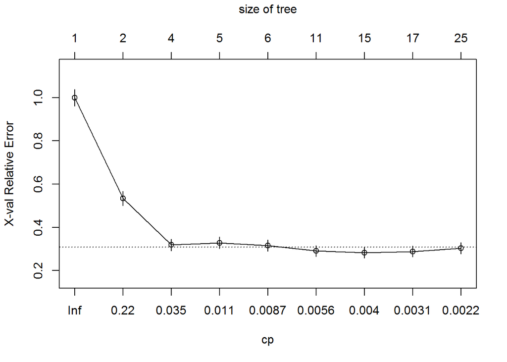

```r
plotcp(mod1, minline = TRUE)
```

[figure not shown]

```r
mod2 <- prune(tree = mod1,cp = 0.035)
fancyRpartPlot(mod2)
```

```r
mod2
```

```
## n= 1000
##
## node), split, n, loss, yval, (yprob)
##       * denotes terminal node
##
##  1) root 1000 399 0 (0.6010000 0.3990000)
##    2) history1=Low,Medium,Missing 745 172 0 (0.7691275 0.2308725)
##      4) Salary< 58650 524  56 0 (0.8931298 0.1068702) *
##      5) Salary>=58650 221 105 1 (0.4751131 0.5248869)
##       10) history1=Low,Medium 99  15 0 (0.8484848 0.1515152) *
##       11) history1=Missing 122  21 1 (0.1721311 0.8278689) *
##    3) history1=High 255  28 1 (0.1098039 0.8901961) *
```